# Heart Disease Data Analysis

2024-10-06

# Introduction

# Data Loading

```r
# Load necessary libraries
library(readr)
library(dplyr)
# Load data from the specified local directory
data <- read_csv("/Users/yezifan/Desktop/data550/exercise-folder/heart.csv")
# Display the first few rows of the data
head(data)
```

```
## # A tibble: 6 × 14
##     age   sex    cp trestbps  chol   fbs restecg thalach exang oldpeak slope
##   <dbl> <dbl> <dbl>    <dbl> <dbl> <dbl>   <dbl>   <dbl> <dbl>   <dbl> <dbl>
## 1    52     1     0      125   212     0       1     168     0     1       2
## 2    53     1     0      140   203     1       0     155     1     3.1     0
## 3    70     1     0      145   174     0       1     125     1     2.6     0
## 4    61     1     0      148   203     0       1     161     0     0       2
## 5    62     0     0      138   294     1       1     106     0     1.9     1
## 6    58     0     0      100   248     0       0     122     0     1       1
## # ℹ 3 more variables: ca <dbl>, thal <dbl>, target <dbl>
```

#descriptive analysis

This section summarizes key characteristics of age, serum cholesterol levels, chest pain type, and heart disease presence using descriptive statistics.

```r
# Load necessary libraries
library(gtsummary)
library(dplyr)

# Create a descriptive statistics table for the selected variables
summary_table <- data %>%
  select(age, chol, cp, target) %>%
  tbl_summary(by = target) %>%  # Group by target variable
  modify_header(label ~ "Variable")

# Display the summary table
summary_table
```

| Variable | **0** N = 499<sup>1</sup> | **1** N = 526<sup>1</sup> |
| --- | --- | --- |
| age | 58 (52, 62) | 52 (44, 59) |
| chol | 249 (217, 284) | 234 (208, 266) |
| cp |  |  |
| 0 | 375 (75%) | 122 (23%) |
| 1 | 33 (6.6%) | 134 (25%) |
| 2 | 65 (13%) | 219 (42%) |
| 3 | 26 (5.2%) | 51 (9.7%) |

<sup>1</sup> Median (Q1, Q3); n (%)

#Graphical Analysis

A scatter plot illustrates the relationship between serum cholesterol levels and age, differentiated by heart disease presence.

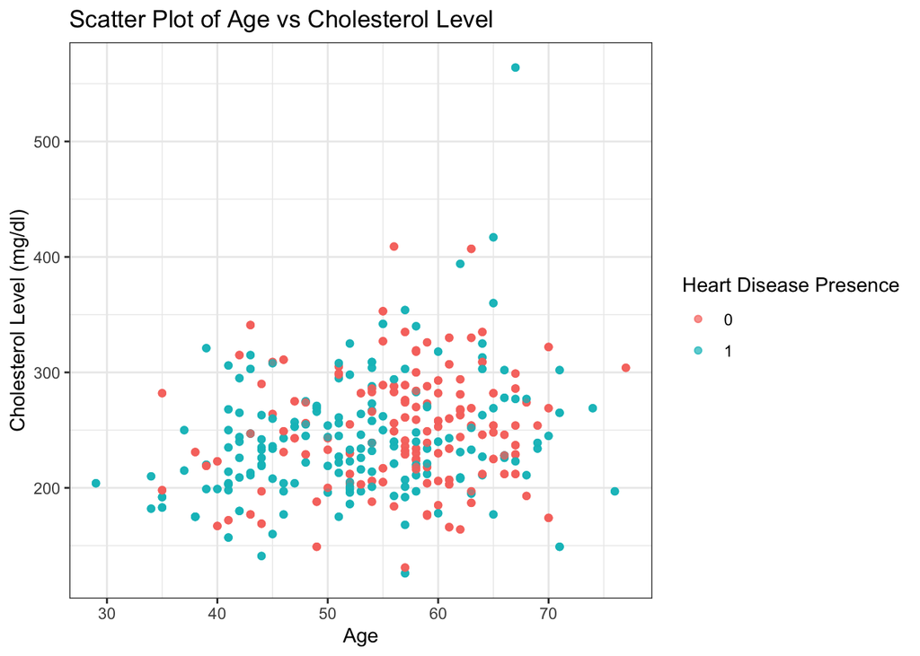

```r
# Load necessary libraries
library(ggplot2)

# Create a scatter plot of age vs cholesterol, colored by target
ggplot(data, aes(x = age, y = chol, color = as.factor(target))) +
  geom_point(alpha = 0.7) +
  labs(
    title = "Scatter Plot of Age vs Cholesterol Level",
    x = "Age",
    y = "Cholesterol Level (mg/dl)",
    color = "Heart Disease Presence"
  ) +
  theme_bw()
```

#Regression Analysis

This section employs a generalized linear model to examine how age, serum cholesterol levels, and chest pain type affect the likelihood of heart disease. # Fit the primary regression model

```r
mod <- glm(
  target ~ age + chol + cp,
  data = data
)

# Display the regression table
tbl_regression(mod) |>
  add_global_p()
```

| **Characteristic** | **Beta** | **95% CI**<sup>1</sup> | **p-value** |
| --- | --- | --- | --- |
| age | -0.01 | -0.01, -0.01 | <0.001 |
| chol | 0.00 | 0.00, 0.00 | 0.4 |
| cp | 0.20 | 0.18, 0.23 | <0.001 |

<sup>1</sup> CI = Confidence Interval

#Secondary Model

A binary outcome model is fitted to analyze the relationship between the same predictors and the presence of heart disease, displaying odds ratios for interpretation. # Fit the secondary regression model

```r
binary_mod <- glm(
  I(target == 1) ~ age + chol + cp,
  data = data,
  family = binomial()
)

# Display the regression table with exponentiated coefficients
tbl_regression(binary_mod, exponentiate = TRUE) |>
  add_global_p()
```

| **Characteristic** | **OR**<sup>1</sup> | **95% CI**<sup>1</sup> | **p-value** |
| --- | --- | --- | --- |
| age | 0.95 | 0.93, 0.96 | <0.001 |
| chol | 1.00 | 1.00, 1.00 | 0.4 |
| cp | 2.63 | 2.28, 3.06 | <0.001 |

<sup>1</sup> OR = Odds Ratio, CI = Confidence Interval